## Loading data

```r
data <- read.csv("activity.csv")
```

## What is mean total number of steps taken per day?

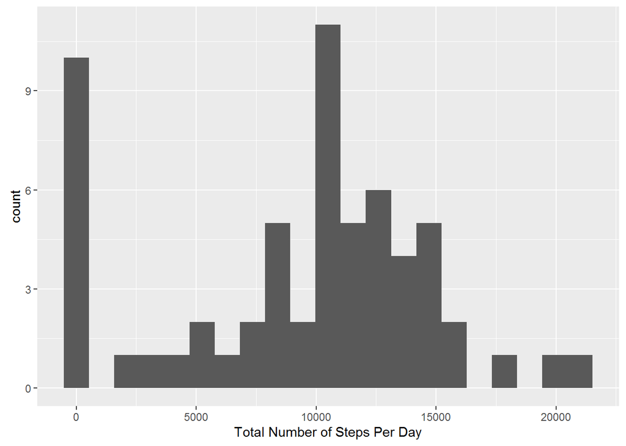

```r
## Creating plot - chunk-1
library(ggplot2)
total.steps <- tapply(data$steps, data$date, FUN=sum, na.rm=TRUE)
qplot(total.steps, binwidth=1050, xlab="Total Number of Steps Per Day")
```

```r
mean(total.steps, na.rm=TRUE)
```

```
## [1] 9354.23
```

```r
median(total.steps, na.rm=TRUE)
```

```
## [1] 10395
```

## What is the average daily activity pattern?

Creating plot with average number of steps

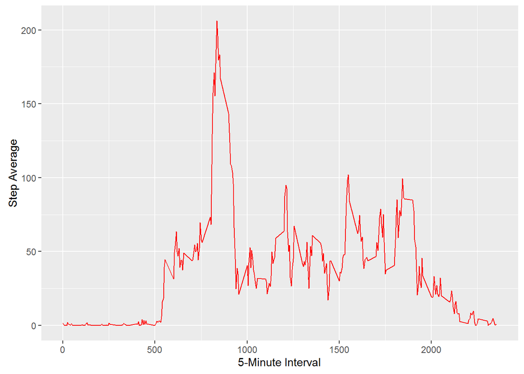

```r
## creating plot - chunk-2
library(ggplot2)
averages <- aggregate(x=list(steps=data$steps), by=list(interval=data$interval),
            FUN=mean, na.rm=TRUE)

ggplot(data=averages, aes(x=interval, y=steps)) +
   geom_line(colour="red") +
   xlab("5-Minute Interval") +
   ylab("Step Average")
```

The average across all the days in the dataset.

```r
averages[which.max(averages$steps),]
```

```
##     interval    steps
## 104      835 206.1698
```

## Imputing missing values

If there is missing data (NA), replacing the missing data with the mean of the intervals should keep any bias towards those values down.

```r
## Missing data
missing <- is.na(data$steps)
table(missing)
```

```
## missing
## FALSE  TRUE
## 15264  2304
```

Missing values replaced with 5-minute interval mean.

```r
# Replace missing values with mean value of the 5-minute interval mean
fill.value <- function(steps, interval) {
   filled <- NA
      if (!is.na(steps))
            filled <- c(steps)
      else
            filled <- (averages[averages$interval==interval, "steps"])
         return(filled)
}
filled.data <- data
filled.data$steps <- mapply(fill.value, filled.data$steps, filled.data$interval)
```

Using the preppared data, it is now time to create a plot

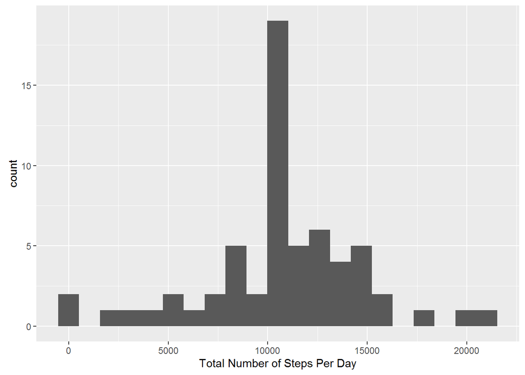

```r
## Finding the total number of steps per day
## creating plot - chunk-3
total.steps <- tapply(filled.data$steps, filled.data$date, FUN=sum)
qplot(total.steps, binwidth=1050, xlab="Total Number of Steps Per Day")
```

```r
mean(total.steps)
```

```
## [1] 10766.19
```

```r
median(total.steps)
```

```
## [1] 10766.19
```

## Are there differences in activity patterns between weekdays and weekends?

1 Find the days of the week for the measurements.  
2 create a plot to show the differences between weekdays and weekends.

```r
## Setting up days of the week
weekday.or.weekend <- function(date) {
   day <- weekdays(date)

      if (day %in% c("Monday", "Tuesday", "Wednesday", "Thursday", "Friday"))
            return("Weekday")

      else if (day %in% c("Saturday", "Sunday"))
            return("Weekend")

      else
            stop("Invalid Date")
}

filled.data$date <- as.Date(filled.data$date)
filled.data$day <- sapply(filled.data$date, FUN=weekday.or.weekend)
```

Part 2 The Plot Weekdays VS Weekends

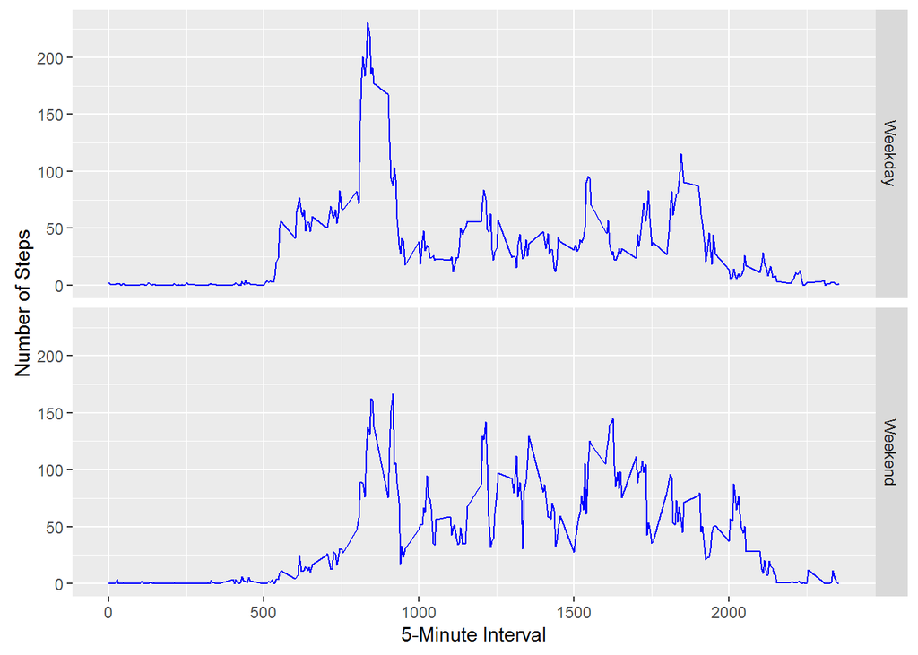

```r
## aggregating the number of steps by intervals
averages <- aggregate(steps ~ interval + day, data=filled.data, mean)
## creating plot - chunk-4
ggplot(averages, aes(interval, steps)) + geom_line(colour="blue") + facet_grid(day ~ .) +
   xlab("5-Minute Interval") + ylab("Number of Steps")
```